**- Work in Progress -**

**Using Wikipedia and Google data to estimate near real-time influenza incidence in Germany: A Tutorial in R**

**Paul Schneider**, *Maastricht University, Netherlands Institute of Health Service Research*  
**John Paget**, *Netherlands Institute of Health Service Research*  
**Peter Spreeuwenberg**, *Netherlands Institute of Health Service Research*  
**David Barnett**, *Maastricht University*  
**Christel van Gool**, *Maastricht University*  
**Contact: schneider.paulpeter@gmail.com**

## Summary

Traditional surveillance systems are costly and involve considerable delay between disease onset and reporting. Previous studies have demonstrated that it is possible to predict the incidence of influenza from relevant Google search queries and Wikipedia page view statistics. Here, we present our approach on how to build a near real-time (‘Nowcast’) prediction model for monitoring the incidence of influenza in Germany using the statistical software R. Source code and data are fully available and can be re-used, adjusted and transferred to other settings.

**Also see our research paper on this topic: In preparation**  
**And have a look at our Github page**

#### **TL;DR**: Code only version

#### Results at a glance: ‘Nowcasting’ Influenza in Germany

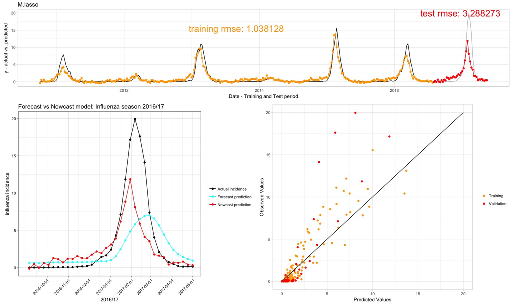

```
export all code only:
knitr::purl(file.choose(),output = "test2.R")
```

## Scope

The aim of this tutorial is to set up a model for predicting the influenza incidence (lab-confirmed cases) in Germany in near real-time (‘Nowcasting’), by using data from various sources. We built on the work of previous studies and integrate a number of proven techniques. For a conceptual discussion of the data sources and methods used, please see our research paper on this topic: In preparation

We will begin with getting information on influenza incidence in Germany, since the availability of the outcome data determines the scope and time horizon of the model we build. We then identify and download information on relevant search queries from Google Correlate and Google Trends and retrieve page view statistics for Wikipedia articles. The datasets have to be formatted, merged, split and pre-processed, before they can enter into the model. Subsequently, we will use various statistical learning methods to build prediction models. Finally, we will compare the different models in terms of predictive accuracy and select the best model to predict this week’s influenza activity.

*We would like to point out that when we speak of ‘prediction’, we use the term in its [statistical sense](https://en.wikipedia.org/wiki/Prediction#Statistics). We do not mean ’forecasting’. We are ‘Nowcasting’: We observe what people are doing on the internet during this week and infer from this information how many influenza cases there are now.*

### Transferability

If you want to apply our methods to another setting and build a first exploratory nowcast model, the code provided in this tutorial should be able to handle most steps automatically. What you need to get started is weekly incidence data on the outcome you want to monitor, over a sufficient time span, and a Google account (to fully take advantage of the functions of Google Correlate). The limiting factors for transferring this tutorial to other settings are probably not only the availability of gold-standard incidence data, but also the quality of the online data, which depend on the share of people who use Wikipedia, Google etc. for health information purposes.

It should be noted that even though this tutorial focuses on influenza, our approach can, in principle, be applied to other diseases as well. Ebola, Chicken Pox, [malaria](https://www.ncbi.nlm.nih.gov/pmc/articles/PMC4228243/) are just a few examples of diseases for which digital epidemiology has shown interesting results. However, some of the features of influenza make it easier to detect relevant predictors and monitor its activity. First, influenza has a strong seasonality (in most countries). Diseases with a more stable incidence might not have enough variation to distinguish signal and noise. Second, during an influenza season many people (5% to 20% of the population) get sick, creating a very strong signal. And finally, influenza has specific symptoms; Diseases with only subtle or non-specific symptoms (say, fatigue) are certainly more problematic to track.

### Getting started

#### Load R-packages

Before building the model, we need to install and load the required R-packages. This may take a while and you may be asked to restart your R session.

```r
# Install and load all required packages
# This may take a while...
required_packages<-c("knitr","RCurl","ISOweek","jsonlite","ggplot2","prophet","dplyr","gtrendsR","wikipediatrend","pageviews","caret","imputeTS","gridExtra","cowplot","corrplot","doParallel","glmnet", "Cubist","pls","devtools","plotmo","plotrix","TeachingDemos","earth","kernlab","rpart","party","grid","zoo","mvtnorm","modeltools","stats4","strucchange","sandwich","elasticnet","lars","randomForest","ipred","e1071","repmis","nnet","gbm","survival","plyr","latticeExtra","shiny") #
pft_packages <- function(package){
    for(i in 1:length(package)){
      if(eval(parse(text=paste("require(",package[i],")")))==0) {
        install.packages(package)}}
    return (eval(parse(text=paste("require(",package,")"))))}
pft_packages(required_packages)
#
# 'gtrendsR' has to be the developer version, to work properly.
# If you don't have it already, install it through github:
#  devtools::install_github("PMassicotte/gtrendsR")
#  library(gtrendsR)
```

#### Set key parameters

**Next, we are going to set a few key parameters, to determine the context of our model:**

Useful links:

- [ISO_3166-2 Country list for Google Trends](https://en.wikipedia.org/wiki/ISO_3166-2)
- [ISO_639-1 language list for Wikipediatrends](https://en.wikipedia.org/wiki/List_of_ISO_639-1_codes)

```r
# What is the outcome of interest?
term = "Influenza" #  Outcome of interst
# For which country do we want to build the model?
country_of_interest = "DE" # this is Germany in ISO_3166-2
# Which language is relevant?
language_of_interest = "de" # German in ISO_639-1
# What the relevant time horizon (i.e. the time span we have data for)
from = as.Date("2010-07-31") # Start
to = as.Date("2017-07-31") # End
# How do we split the data into training and test data?
split.at = as.Date("2016-08-01")
# --> Training data:  2010-07-31 - 2016-08-01
# --> Test Data:      2016-08-02 - 2017-07-31
```

## Get data

#### Data sources

Actual influenza incidence outcome data are taken from the [Robert Koch Institute](https://survstat.rki.de/Content/Query/Select.aspx). As potential predictors we will use page view statistics of Wikipedia pages, accessed via the Wikipedia-page view-[API](https://wikitech.wikimedia.org/wiki/Analytics/AQS/Pageviews) and [Wikishark](http://www.wikishark.com/), and search query statistics from Google, accessed via [Google Correlate](https://www.google.com/trends/correlate/) and [Google Trends](https://trends.google.com/trends/). The analyses are performed using the statistical software [R/R Studio](https://www.rstudio.com/), and numerous of its packages - Please see References for a complete list. The source code and all data used in this tutorial are either provided here or on our github page.

#### Outcome data

Influenza incidence data (cases per per 10,000) for Germany, from August 2010 to August 2017, can be downloaded from the website of the Robert Koch Institute. On [Survstat](https://survstat.rki.de/Content/Query/Select.aspx) you can build your own customized data query. The data used in this example can be found on github (see code chunk below).

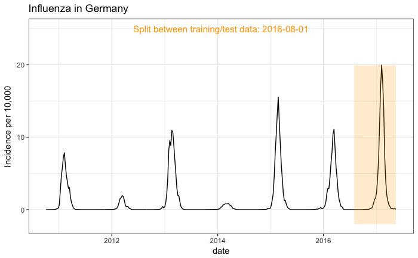

```r
# Load outcome data from github repository
influenza.de = read.csv("https://raw.githubusercontent.com/projectflutrend/pft.2/master/outcome%20data/RKI.data.de.csv")
names(influenza.de) = c("date","y")
# Re-formatting 'date', and deleting irrelevant data points
influenza.de$date = paste(sub("w","W", influenza.de$date),"-1", sep="")
influenza.de$date  = ISOweek2date(influenza.de$date)
influenza.de = influenza.de[influenza.de$date>as.Date("2010-07-31") & influenza.de$date<=as.Date("2017-07-31"),]
# The RKI data does not report data during summer months,
# in which there are basically no cases of viral influenza in Germany.
# Since we want to have a model that predicts those zero-months as such as well,
# we will fill the gaps with zeros
reference =data.frame(date = seq(from=min(influenza.de$date),
                                 to=max(as.Date(influenza.de$date)),
                                 by=7))
influenza.de = merge(reference,influenza.de,by="date",all=T)
influenza.de$y[is.na(influenza.de$y)] = 0
# Plotting the data
ggplot(influenza.de,aes(x=date,y=y)) +
  geom_line() + theme_bw() +
  annotate("rect", xmin=split.at, xmax=max(influenza.de$date)+2,
           ymin=min(influenza.de[,2])-2, ymax=max(influenza.de$y),
           fill="orange",alpha=0.2) +
  annotate("text",
           x=median(influenza.de$date), y=25,
           label= paste("Split between training/test data:",split.at),
           size=4,col="orange") + ylab("Incidence per 10,000") +
  ggtitle("Influenza in Germany")
```

The figure shows the influenza seasons 2010/2011 to 2016/2017, in Germany. The orange-shaded area is the data we are going to use to validate our model. Reported are ‘laboratory-confirmed influenza cases’. Flu-like symptoms that occur during the summer months are not caused by the influenza virus (these cases are referred to as ‘influenza-like illness’ (ili) and might be easier to monitor with syndromatic surveillance. The data, however, are not openly available).

#### Wikipedia data

In many countries, Wikipedia is the leading source of health information - not only for patients, but also for health professionals- and it is often used as a starting point for online self-education [IMS](http://www.imshealth.com/files/web/IMSH%20Institute/Reports/Engaging%20Patients%20Through%20Social%20Media/IIHI_Social_Media_Report_2014.pdf). In 2014, [McIver & Brownstein](http://journals.plos.org/ploscompbiol/article?id=10.1371/journal.pcbi.1003581) claimed that Wikipedia usage (i.e, information on how many people visited a Wikipedia article on a particular day) could predict ili intensity in the US more accurately than Google Flu Trends. Although their methods had some limitations (They did not clearly separate training and test data), the study demonstrated the potential utility of Wikipedia page view data for a Nowcast model.

Wikipedia’s pageview data is openly available via it’s [API](https://wikitech.wikimedia.org/wiki/Analytics/AQS/Pageviews) (for data from October 2015 until today) and via [Wikishark](http://www.wikishark.com/) (for data from January 2008 until December 2016). The main article of interest will be the German Wikipedia page on Influenza. In addition, we also explore the possibility to identify further relevant Wikipedia pages by automatically extracting titles of articles that refer *to* or that are referred to *from* the page of interest: e.g. The ‘influenza vaccine’ article links to the ‘influenza’ article; and the ‘influenza’ article links to an article on ‘aspirin’ etc.). Another useful aspect is the fact that Wikipedia articles with similar content are linked across languages. Using the [Wikipediatrend package](https://cran.r-project.org/web/packages/wikipediatrend/README.html) it is, for example, possible to identify the article on ‘influenza’ in about 80 different Wikipedia projects.

```r
# Run the code below to identify articles on influenza in other languages
wikipediatrend::wp_linked_pages( page= "Influenza", lang="en")
```

There is, however, an important downside to using Wikipedia page view data that needs to be mentioned: The main problem with Wikipedia is that information on viewers locations are not available. Language has to be used as a proxy. This is a limiting factor for the use of Wikipedia data in some countries with larger language regions (e.g. English, Spanish). Wikimedia has a site where you can look up the shares of Wikipedia traffic per [country](https://stats.wikimedia.org/wikimedia/squids/SquidReportPageViewsPerCountryBreakdown.htm) and per [language](https://stats.wikimedia.org/wikimedia/squids/SquidReportPageViewsPerLanguageBreakdown.htm). Furthermore, Wikipedia is not static. New pages are created and old pages may be changed or merged; And the promotion of a particular Wikipedia page on the main Wikipedia page may cause surprising peaks in page view statistics.

##### Download Wikipedia data

First, we identify articles which are linking to (‘back-links’) and articles that are linked from the German Wikipedia page on Influenza. In addition, we can choose to add additional Wikipedia pages manually if we believe they could be relevant. Subsequently, we are downloading page view statistics for all the articles.

The functions are uploaded on github where they can be viewed.

**At the moment, functions only work for the given time span**

```r
# Loading functions from github:
wiki.functions <- getURL("https://raw.githubusercontent.com/projectflutrend/pft.2/master/quickfunctions/pft_ask_wikipedia")
eval(parse(text = wiki.functions)) # contains two functions: pft_wiki_lp() and pft_ask_wikipedia()

# Retrieve linked and 'backlinked' articles
wiki.pages = pft_wiki_lp(term = "Influenza",              # primary page of interest
                         language_of_interest = "de",     # Wikipedia project language
                         backlinked = 1,                  # Also want to retrieve backlinks?
                         manual.pages=c("Halsschmerzen",  # adding 2 terms manually:
                                        "Hausmittel"))    # "Halsschmerzen" (= sore throat)
                                                          # and "Hausmittel" (= home remedy)
                                                          # If not used, set to 'NULL'
str(wiki.pages)
#
# Now, page view statistcs for these 603 pages can be downloaded
# Expect download times of approximately 1.5 seconds per page
# Download from Wikishark and Wikipedia API
# Data comes aggregated per week
#
wikipedia.input.data = pft_ask_wikipedia(pages = wiki.pages,            # Wikipedia article names
                                         language_of_interest =  "de",  # Project language
                                         from = as.Date("2010-01-01"),  # Download from
                                         to = as.Date("2017-07-31"),    # Download up to
                                         status = 0)                    # Print download status
```

We put the data from this tutorial on github:

```r
wikipedia.input.data = read.csv("https://raw.githubusercontent.com/projectflutrend/pft.2/master/input%20data/wikipedia.input.data.de.csv")[,-1]
# Data comes aggregated per week
head(wikipedia.input.data[,1:4])
```

|  | date | wiki.Influenza | wiki.Acetylsalicylsäure | wiki.Adolf_Mayer_.Agronom. |
| --- | --- | --- | --- | --- |
| 1 | 2009-W53 | NA | NA | NA |
| 2 | 2010-W01 | 4910 | 8584 | 27 |
| 3 | 2010-W02 | 5559 | 10942 | 38 |
| 4 | 2010-W03 | 4658 | 8430 | 20 |
| 5 | 2010-W04 | 4654 | 9111 | 29 |
| 6 | 2010-W05 | 4638 | 11290 | 30 |

#### Google Correlate & Google Trends

[Google Correlate](https://www.google.com/trends/correlate/) is a tool that can identify search queries that are highly correlated with any time series data you upload (Even for [randomly generated numbers](https://www.r-bloggers.com/google-correlate-certainly-does-not-imply-causation/) it will find a good match). You can also identify queries that are correlated with other queries. It was a building block of [Google Flu Trend](https://googleblog.blogspot.co.uk/2011/05/mining-patterns-in-search-data-with.html). [Google Trends](https://trends.google.com/trends/) shows how often a particular search-term is entered relative to the total search-volume across various regions of the world. It can also be used to identify related search queries (“People who searched for this, also searched for this”). We will use both tools, serially, to identify and download information on potential predictors. For more information see [paper 1](https://www.google.com/trends/correlate/nnsearch.pdf) and [paper 2](http://people.ischool.berkeley.edu/~hal/Papers/2015/primer.pdf).

##### Using Google Correlate

To identify potential predictors in Google Correlate, we have to prepare and upload our outcome data as a csv. spreadsheet. It is important not to leak any information from the test data in this step - Only use outcome data from the training data set! There is no API available for R, so you need a Google Account and do this in your browser manually. You can also choose to enter keywords and retrieve information on other search terms that are correlated. Note the “shift series” button on the Correlate page: It shifts the data one week in time, in case you think there might be a delay between people using Google and the actual reporting of influenza cases

*For some reason, Google Correlate won’t provide datapoints for recent dates (At the moment, it only provides data untill 2017-03-12). So, we have to retrieve the keywords only and download their statistics in a second step, using Google Trends.*

```r
# Prepare the outcome data in the right format
g.cor.influenza.training.upload = influenza.de[influenza.de$date<split.at,]
#
# Adjusting week format: making Sunday the first day of the week
g.cor.influenza.training.upload$date = g.cor.influenza.training.upload$date-1
#
# Saving the file in your default folder
# write.table( g.cor.influenza.training.upload, col.names=FALSE,row.names = FALSE,sep=",",file="/FILL_IN_A_PATH/g.cor.influenza.training.upload.csv")
#
### --> Now, go to https://www.google.com/trends/correlate/
###     Login, upload the spreadhseet, and download results
```

Upload data to Google Correlate

Google Correlate Results

[figure not shown]

[figure not shown]

We have put the Google Correlate data for this tutorial on github:

```r
g.cor.keywords[1:10]
```

```
 [1] "influenza a"               "influenza"                 "virusgrippe"               "j11 1"                     "grippe fieber"
 [6] "grippe verlauf"            "influenza schnelltest"     "influenza inkubationszeit" "echte grippe"              "grippe bei kindern"
```

If you wonder what “J11 1” might be - It’s the ICD-10 code for Influenza. Doctors print it on the letters for sick leaves. It seems as if some patients were curious what the doctor had diagnosed them with.

##### Using Google trends data

First, we identify 25 search queries related to ‘influenza’ queries. Subsequently, we download search query statistics for the keywords identified by Google Correlate and Google Trends and we also download statistics for queries for ‘influenza’ in Google News. It is also possible to expand your requests by retrieving related keywords of related keyword, feed related keywords into Google Correlate, add more News-related-queries and so on.

**At the moment, functions only work for the given time span**

```r
# Loading functions from github:
google.function <- getURL("https://raw.githubusercontent.com/projectflutrend/pft.2/master/quickfunctions/pft_ask_google")
eval(parse(text = google.function)) # Functions loaded are: pft_ask_google() and Rescale.gtrends()
# Identify 25 related queries
 primer = gtrends(keyword=term,              # term = "influenza"
                  geo=country_of_interest,  # "DE" = Germany in ISO_3166-2
                  time=paste(from,to),      # from= 2010-07-31 to=2017-07-31
                  gprop ="web")             # Search in webqueries
```

We put the Google data on github:

```r
google.input.data = read.csv("https://raw.githubusercontent.com/projectflutrend/pft.2/master/input%20data/google.input.data.de.csv")[,-1]
dim(google.input.data)
```

```
[1] 366 128
```

```r
head(google.input.data[,1:4])
```

|  | date | g.cor.influenza.a | g.cor.influenza | g.cor.virusgrippe |
| --- | --- | --- | --- | --- |
| 1 | 2010-W30 | 2.9 | 5 | 5.1 |
| 2 | 2010-W31 | 5.0 | 4 | 5.1 |
| 3 | 2010-W32 | 2.9 | 6 | 5.1 |
| 4 | 2010-W33 | 3.6 | 6 | 7.2 |
| 5 | 2010-W34 | 5.7 | 7 | 7.2 |
| 6 | 2010-W35 | 5.7 | 8 | 4.1 |

#### Time-lag

**Timeline:**

> Infection-> Disease onset-> Consultation-> Diagnosis -> Reporting to local health authority -> Reporting to National authority -> Public reporting

If you expect a lag between the signal in your predictors and the response in the gold-standard outcome variable, you might want to experiment with shifting your data sets and re-running your models with one or two weeks time lag (Also note the shift series button on Google Correlate). But be cautious: When there is a signal in your predictor data only after cases are reported, the underlying mechanism, and the utility of such a model appear to be questionable. For the data in this tutorial, we did not see (nor did we expect) any improvement by shifting time series, so we do not use it here.

```r
# Not used for our analysis
# Time lag 1 week = The online signal in week v predicts the cases of week v+1
google.input.data$date = ISOweek(ISOweek2date(paste(google.input.data$date,-1,sep="")) + 7)
wikipedia.input.data$date = ISOweek(ISOweek2date(paste(wikipedia.input.data$date,-1,sep="")) + 7)
```

#### Merging

Now that we have all the data we need, we can merge the files into one data frame.

```r
# full data set available at
# https://raw.githubusercontent.com/projectflutrend/pft.2/master/input%20data/df.full.de.csv
# Combining outcome, wikipedia, google trends and google correlate
influenza.de$date = ISOweek(influenza.de$date )
# Merging by week (avoiding any Monday/Sunday or other day issues)
df.full = merge(influenza.de,google.input.data, by="date")
df.full = merge(df.full,wikipedia.input.data, by="date")
# Setting date back to a date
df.full$date = ISOweek2date(paste(df.full$date,"-1",sep="")) #
cat("Full data set:",dim(df.full)[1], "Weeks and",dim(df.full)[2]-2,"Predictors")
```

```
Full data set: 346 Weeks and 535 Predictors
```

## Pre-processing

Before the data is used to build prediction models, it is split in to training/tuning and test/validation data. Also, we have to deal with missing observations, remove predictors with too little variance, transform skewed predictors, think about multi-collinearity and bring all predictors to a common scale.

#### Splitting the data

Splitting the data into predictor and outcome, as well as training and testing data sets.

```r
# Remeber: 'split.at' defines the date which separates training and test/evaluation data
split = which(df.full$date<split.at)
df.train = df.full[split,-c(1,2)] # Predictor training data set
y.train = df.full[split,c(2)] # Outcome for training data set
date.train = df.full[split,c(1)] # Date, not a predictor but useful for plotting
df.test  = df.full[-split,-c(1,2)] # Predictors for testing/evaluation data set
y.test = df.full[-split,c(2)] # Outcome for testing data set
date.test = df.full[-split,c(1)] # date for test data set
```

#### Missing data points

```r
# Removing features with >10% NAs
  # in training
  sum.NA.train = as.numeric(lapply(df.train,function(x){sum(is.na(x))}))
  sum.NA.train = sum.NA.train > length(df.train[,1]) * 0.1
  if(sum(sum.NA.train)>0){
  df.train = df.train[-which(sum.NA.train)]
  df.test = df.test[which(colnames(df.test) %in% colnames(df.train))]}
  # and test data separately
  sum.NA.test = as.numeric(lapply(df.test,function(x){sum(is.na(x))}))
  sum.NA.test = sum.NA.test > length(df.test[,1]) * 0.1
  if(sum(sum.NA.test)>0){
  df.test = df.test[-which(sum.NA.test)]
  df.train = df.train[which(colnames(df.train) %in% colnames(df.test))]}

# Imputing remaining NAs
  df.train = na.ma(df.train , k = 3, weighting = "exponential")
  df.test = na.ma(df.test , k = 3, weighting = "exponential")
```

#### Low variance predictors

Furthermore, we want to remove predictors that have near zero variance. This means they have few unique values. Prediction models can be adversely affected by these near zero variance predictors. You might also consider removing predictors that have a very low activity, because results could be very unstable if models put much weight on them (a random increase in interest could distort our model).

```r
# Removing features with near zero variance
  # identify near zero-variance predictors [only in df.train!]
  nearZeroVar = nearZeroVar(df.train,freqCut = 95/5 , uniqueCut = 25)
  if(sum(nearZeroVar)>0){
  df.train = df.train[,-nearZeroVar]
  df.test = df.test[which(colnames(df.test) %in% colnames(df.train))]}
```

#### Center - Scaling - Skewness reduction

Predictors should be [scaled](https://en.wikipedia.org/wiki/Standard_score) (each value of a predictor is divided by its standard deviation) and centred (All predictor have a mean of zero). This can improve the performance of some of the modelling techniques and makes it easier to compare predictors’ influence. Furthermore, many of our predictors are heavily right-skewed. In order to improve the performance of some of our modelling techniques, we will use the [‘BoxCox’](https://en.wikipedia.org/wiki/Power_transform#Box.E2.80.93Cox_transformation) function which automatically determines a transformation that is appropriate to to make the data more normally distributed.

```r
# Scaling, centering, transofrmation and imputation of remaining NAs by K-nearest neighbours
  preprocess.df.train = preProcess(df.train, method=c("scale","center","BoxCox"))
  df.train = predict(preprocess.df.train, newdata = df.train)
  df.test = predict(preprocess.df.train,newdata = df.test)
```

#### Mutli-collinarity

Many of our predictors are strongly correlated with each other - especially the Google Correlate predictor set (see figure below).

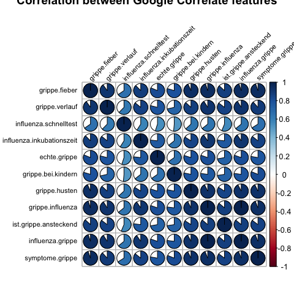

```r
# Example: Assessing multicolinerity
# Selecting a subset and plotting the correlation matrix
subset.g.cor = google.input.data[,6:16]
names(subset.g.cor) = gsub("g.cor.","",names(subset.g.cor))
correlation.matrix = cor(subset.g.cor)
corrplot::corrplot(correlation.matrix,method="pie", title="Correlation between Google Correlate features",tl.pos="lt",tl.cex=0.7, tl.col ="black", tl.srt=45)
```

To tackle this issue, you might consider removing some of the predictors, or use principal component analysis (PCA), to reduce the number of predictors by creating a smaller set of uncorrelated components. However, PCA is unsupervised, i.e. it is not guided by the outcome variable when reducing dimensions (in contrast to PLS, see below). For PCA in R, you can use the code below or specify it later in the modeling step. Since we did not observe any improvement using PCA, we do not cover it in more depth.

```r
# Not used in our analysis - PCA:
 PCA.proces = preProcess(df.raw, method=c("pca"),  # principal component analysis
                                    thresh=0.95)   # a cutoff for the cumulative percent of variance
                                                   # to be retained by PCA
 df.pca = predict(PCA.proces, newdata = df.raw)
```

## Model building

#### Modelling techniques

We will fit and train 12 different types of models over a range of tuning parameters and let them, sort of, compete against each other, using time series cross validation (see below). The model that produces predictions with the lowest deviation from observed values, in terms of [root-mean-squared-error](https://en.wikipedia.org/wiki/Root-mean-square_deviation)(rmse) (wins and) will be selected for the nowcasting task.

|  | Model: R-function |
| --- | --- |
| 1 | [Partial least squares: pls](https://en.wikipedia.org/wiki/Partial_least_squares_regression) |
| 2 | [Ridge regression: enet](https://en.wikipedia.org/wiki/Tikhonov_regularization) |
| 3 | Lasso regression: glmnet |
| 4 | [Multivariate adaptive regression splines: earth](https://en.wikipedia.org/wiki/Multivariate_adaptive_regression_splines) |
| 5 | [Support vector machine: svmradial](https://en.wikipedia.org/wiki/Support_vector_machine) |
| 6 | [Single trees: rpart](https://en.wikipedia.org/wiki/Recursive_partitioning) |
| 7 | [Single trees: ctree](https://en.wikipedia.org/wiki/Decision_tree_learning) |
| 8 | [Boosted trees: gbm](https://en.wikipedia.org/wiki/Gradient_boosting#Gradient_tree_boosting) |
| 9 | [Bagged trees: treebag](https://en.wikipedia.org/wiki/Bootstrap_aggregating) |
| 10 | [Random forest: rf](https://en.wikipedia.org/wiki/Random_forest) |
| 11 | [Cubist: cubist](https://cran.r-project.org/web/packages/Cubist/vignettes/cubist.pdf) |
| 12 | [Neural Network: AvNNet](https://en.wikipedia.org/wiki/Artificial_neural_network) |

#### Parallel computing

Some of the models require quite a bit of computational power. The time it takes to run them can be significantly reduced by using parallel computing, in which computations are executed simultaneously.

```r
# parallel computing
no_cores <- detectCores() - 1
# FOR MAC
cl <- makeCluster(no_cores, type="FORK")
# FOR WINDOWS
# cl <- makeCluster(no_cores, type="PSOCK") # ?!
registerDoParallel(cl)
```

#### Time series cross validation

Cross-validation is a crucial step in building our prediction model. Without it, the large number of predictors and models that are being fit would be quite problematic (For an R-tutorial on CV see [R-Tutorial](http://www.milanor.net/blog/cross-validation-for-predictive-analytics-using-r/)). However, usual split-sample cross validation would be problematic, since we are dealing with time series data. A random split of the data, or splitting the data based on season-year, would leak information from the future to the past. This is a critical issue in predictors that loose or gain predictive power over time. Consider the following simple example: When we train a model with data from 2010 and 2012 and validate it with data from 2011, information about the predictive power of the keyword ‘influenza 2010’ (which is very high in 2010 but low in 2011) is leaked from 2012 (where it is also low) to 2010. Thus, the model would provide overly optimistic results for the 2011 cross-validation hold-out.

In order to get realistic results, we will use ‘time series cross validation’. This means, we will train a model using the data from the first data point until week x and validate the results using data from the next k-weeks. In each validation round, we will move 1 week forward, while the origin stays the same. The amount of data the model is being trained on increases with every round. k = 52 represents the number of weeks for which the model is being tested: It also implies that the model remains the same for a whole year without being re-fit.

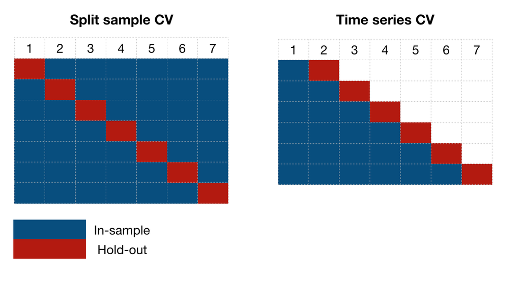

```r
# Specifying time series cross-validation
controlObject <- trainControl(method = "timeslice",
                              initialWindow = 52,  # First model is trained on 52 weeks (x)
                              horizon = 52, #4?!   # Validation weeks (k)
                              skip = 0,            # Skip weeks to decrease CV-folds
                              fixedWindow = FALSE, # Origin stays the same
                              allowParallel = TRUE)# Paralel computing can speed things up
```

#### Model fitting and tuning

**Cave:** Running the code below can take several hours or even days, depending on the hardware you are using! Results of our analysis can be downloaded from github, see below.

```r
# partial least square
  M.pls = train(y= y.train ,
              x = df.train,
              method = "pls",
              tuneLength = 10,
              trControl = controlObject)

# ridge regression (enet)
  ridgeGrid <- expand.grid(.lambda = c(.001, .01, .1),.fraction = seq(0.005, 0.3, length = 30))
  # model
  M.ridge  = train(y= y.train ,
                 x = df.train,
                 method = "enet",
                 tuneGrid = ridgeGrid,
                 trControl = controlObject)

# lasso regression (glmnet)
  lassoGrid <- expand.grid(.alpha = c(.2, .4, .6, .8),.lambda = seq(.05, 1.5, length = 50))
  # Model
  M.lasso <- train(y= y.train ,
                     x = df.train,
                     method = "glmnet",
                    family = "gaussian", # tried poisson, worse!
                    tuneGrid = lassoGrid,
                    trControl = controlObject)

# multivariate adaptive regression splines (earth)
  marsGrid <- expand.grid(.degree = 1, .nprune = 2:15)
  # Model
  M.mars=train(y= y.train ,
          x = df.train,
          method = "earth",
          tuneGrid = marsGrid,
          trControl = controlObject)

    # varImp(M.mars)

# radial support vector machine (svmRadial)
  rsvmGrid <-  expand.grid(sigma= 2^c(-25: -2), C= 2^c(4:6))
  # Model
  M.rsvm = train(y= y.train ,
              x = df.train,
              method = "svmRadial",
              tuneLength = 25,
              tuneGrid =rsvmGrid,
              trControl = controlObject)

# Single regression trees 1 (rpart)
  M.rpart = train(y= y.train ,
                x = df.train,
                method = "rpart",
                tuneLength = 30,
                trControl = controlObject)

# Single regression trees 2 (cpart)
  M.ctree = train(y= y.train ,
                x = df.train,
                method = "ctree",
                tuneLength = 30,
                trControl = controlObject)

# Bagged trees (treeBag)
  M.bagtree = train(y= y.train ,
                      x = df.train,
                      method = "treebag",
                      trControl = controlObject)

# Random forest (rf)
  M.rf = train(y= y.train , ### takes too long!!!
              x = df.train,
              method = "rf",
              tuneLength = 10,
              ntrees = 500,
              importance = TRUE,
              trControl = controlObject)

# Boosted tree (gbm)
  boostGrid = expand.grid(.interaction.depth = seq(3, 9, by = 2), .n.trees = seq(100, 2000, by = 100),.shrinkage = c(0.01, 0.1),.n.minobsinnode = c(10))
  # Model
  M.boost = train(y= y.train ,
                  x = df.train,
                  method = "gbm",
                  tuneGrid = boostGrid,
                  verbose = FALSE,
                  trControl = controlObject)

# Cubist (cubist)
  cubistGrid <- expand.grid(.committees = seq(0,100,by=10),.neighbors=c(0,1,5,9))
  # Model
  M.cubist = train(y= y.train ,
                   x = df.train,
                   method = "cubist",
                   tuneGrid = cubistGrid,
                   trControl = controlObject)

# neural network (avNNet)
  nnetGrid <- expand.grid(.decay = c(.01,.05, .1),.size = seq(1, 10, by = 1),.bag = FALSE)
  # model
  M.nnet = train(y= y.train ,
                x = df.train,
                method = "avNNet",
                tuneGrid = nnetGrid,
                preProcess = "pca", # nnet are often affected by multicolinearity
                linout = TRUE,
                trace = FALSE,
                maxit = 500,
                trControl = controlObject)


## Saving results
models.de = list(result.list = list(M.pls = M.pls,
                                    M.ridge = M.ridge,
                                    M.lasso = M.lasso,
                                    M.mars = M.mars,
                                    M.rsvm = M.rsvm,
                                    M.rpart = M.rpart,
                                    M.ctree = M.ctree,
                                    M.bagtree = M.bagtree,
                                    M.rf = M.rf,
                                    M.boost = M.boost,
                                    M.cubist = M.cubist,
                                    M.nnet = M.nnet)
                 , eval.list = list())
```

## Results

The results of this tutorial, and functions for analysis can be loaded from Github:

```r
# read eval function from github
eval.function <- getURL("https://raw.githubusercontent.com/projectflutrend/pft.2/master/quickfunctions/pft_eval_model")
eval(parse(text = eval.function))
# Illustration of CV RMSE over all tuning parameters
rmse.plots.function <- getURL("https://raw.githubusercontent.com/projectflutrend/pft.2/master/quickfunctions/rmse.boxplots")
eval(parse(text = rmse.plots.function))
# Download model results
models.de = list(result.list=list(),eval.list = list())
model.list = c("M.pls","M.ridge","M.lasso","M.mars","M.rsvm","M.rpart","M.ctree","M.bagtree","M.rf","M.boost","M.cubist","M.nnet")
for(m in 1:length(model.list)){
  cat("\n Downloading model",m,"of",length(model.list))
url = paste("https://github.com/projectflutrend/pft.2/blob/master/models/",model.list[m],".de.tutorial.rdata?raw=true",sep="")
source_data(url,rdata=TRUE)
models.de$result.list[[m]] = temp.model[[1]]
names(models.de$result.list)[m]= names(temp.model)
}
```

Extracting model statistics and plots:

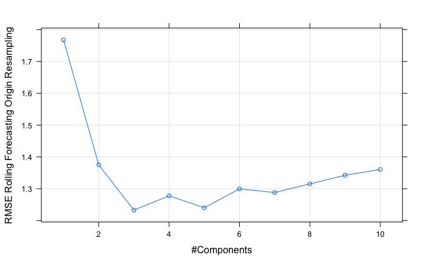

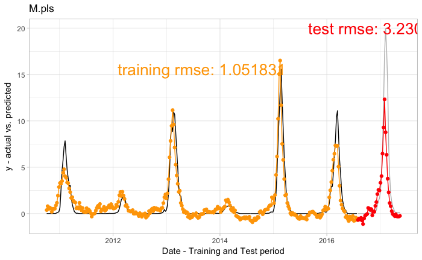

```r
# The functions extractes
models.de$eval.list$M.pls$plots$cv.plot           # CV plot
models.de$eval.list$M.pls$plots$pred.plot         # Predicted versus observed plot

models.de$eval.list$M.pls$correlations$cor.train  # Correlation between obs. and pred. in training dataset
```

```
[1] 0.9127904
```

```r
models.de$eval.list$M.pls$correlations$cor.test   # Correlation between obs. and pred. in test dataset
```

```
[1] 0.8887566
```

```r
models.de$eval.list$M.pls$lowest.rmse             # Mean RMSE over CV holdsouts
```

```
[1] 1.232792
```

### Evaluating the models

First, we should make sure that the ‘grids’ we used for model tuning were specified correctly, and that the model performs as expected. If RMSE do not reach a minimum, or if we want to investigate a minimum in more detail, we can adjust it by correcting the ‘expand.grid’ component. The figure below shows results of tuning parameters on the left, and model predictions within the training and test data set on the right. It is not recommended to base your model selection on either the training RMSE or the test RMSE; We think, the CV RMSE is a much better measure for this. However, training and test predictions might give you some sense of how the different models work.

We only show the lasso example, but by running the code below you can investigate them one by one.

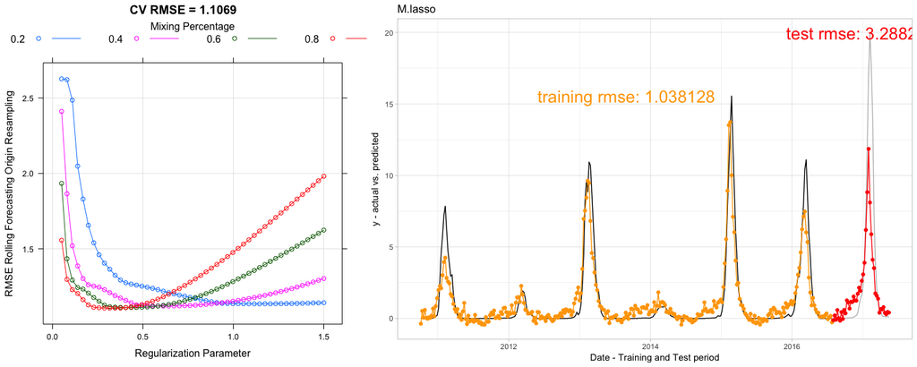

```r
# Run the code below to invesgiate the models one by one
for(model in 1:length(models.de$result.list)){
  grid.arrange(plot(models.de$result.list[[model]],
                    main=paste("CV RMSE =",round(models.de$eval.list[[model]]$lowest.rmse,4))),
             models.de$eval.list[[model]]$plots$pred.plot,ncol=2,widths=2:3)
  readline(prompt="Press [enter] to continue")
}
```

We evaluate the performance of the final models looking at their mean RMSE and SD over CV holdouts. It is important to note, that while a model with a low mean RMSE is the aim of building these models, attention should also be paid to the variability around it. Even if outliers seem to occur only rarely in the models we have build and tested, it is in our interest to avoid high over- or underpredictions.

[figure not shown]

```r
# lowest CV RMSE per model
means=NULL; sd = NULL; model.name = NULL
for(m in 1:length(models.de$result.list)){
  means[m] = mean(models.de$result.list[[m]]$resample$RMSE,na.rm=T)
  sd[m] = sd(models.de$result.list[[m]]$resample$RMSE,na.rm=T)
  model.name[m] = names(models.de$result.list)[m]
}
sd = sd[order(means)]; model.name <- factor(model.name, levels = model.name[order(means)])
means = means[order(means)]; model.name <- factor(model.name, levels = model.name[order(means)])
ggplot() +
  geom_point(aes(x=means,y=model.name)) +
  geom_line(aes(x=c(means-sd,means+sd),y=rep(model.name,times=2))) +
  ggtitle("Model mean RMSE +/- 1 SD") +
  xlab("RMSE") +
  ylab("Model")
```

We can illustrate the plot above in a slightly different way, by plotting the results for each common CV holdout (i.e. the blocks of 52 weeks we test our model on) as a separate line. It reveals that a few models had rare, but serious outliers in their performance. The bold black lines indicate the mean rmse over all holdouts.

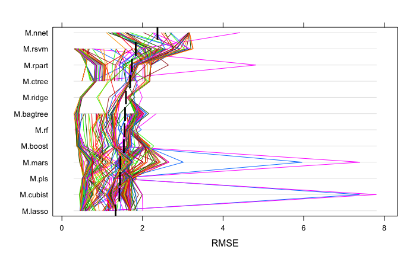

```r
mean.rmse.btp = as.numeric(lapply(models.de$eval.list, function(x){x$lowest.rmse}))
parallel.plot = rmse.plots(models.de$result.list,box=0,parallel = 1)
layer.2 <- xyplot(1:12~mean.rmse.btp[order(mean.rmse.btp)]/8, pch = "l", col = "black", cex=3)
print(parallel.plot + as.layer(layer.2))
```

#### Model Selection

```r
glmnet.fit = glmnet(x = data.matrix(df.train),
                    y = y.train,
                    lambda = models.de$result.list$M.lasso$bestTune$lambda,
                    alpha =  models.de$result.list$M.lasso$bestTune$alpha)
glmnet.coefs <- coef(glmnet.fit, s = "lambda.min")
data.frame(Predictors = glmnet.coefs@Dimnames[[1]][glmnet.coefs@i + 1])
```

| Predictors |
| --- |
| (Intercept) |
| g.cor.virusgrippe |
| g.cor.grippe.verlauf |
| g.cor.influenza.inkubationszeit |
| g.cor.grippe.bei.kindern |
| g.cor.ist.grippe.ansteckend |
| g.cor.wie.lange.dauert.eine.grippe |
| g.cor.verlauf.grippe |
| g.cor.sport.nach.grippe |
| g.cor.wie.lange.dauert.grippe |

[output cut: 7 more lines]

The model selected 16 predictors: 11 from Google Correlate,3 from Google Trends and 2 from Wikipedia (surprisingly, one of which refers to the Wikipedia article on ‘Sachsen Anhalt’, a federal state in Germany).

### Nowcast versus Forecast

It would not be fair to compare a nowcast model against a flat line at the mean, or at zero cases. This would be like a clinical trial with no comparator. In order to compare our model against a ‘placebo’, to stay in the picture, we will build a ‘null-model’, i.e. our nowcast model should *at least* be better than a forecast model. For this purpose, we fit a forecast model on the training data set (seasons 2010/2011-2015/2016), using the [prophet forecasting package](https://research.fb.com/prophet-forecasting-at-scale/), created by Facebook researchers.

```r
# Forecasting - null model
null.model = prophet(df=data.frame(ds = date.train,
                           y=y.train),
             growth = "linear",
             yearly.seasonality = T,
             weekly.seasonality = F)
```

```
Initial log joint probability = -6.91857
Optimization terminated normally:
  Convergence detected: relative gradient magnitude is below tolerance
```

```r
forecast = make_future_dataframe(null.model, periods = 365)
null.model.forecast = predict(null.model, forecast)
p = plot(null.model, null.model.forecast) +
  geom_point(data=data.frame(date.test,y.test),aes(x=date.test,y=y.test),col="pink",lty="dashed", size=2)
```

Now, we compare the predictions of the forecast and nowcast model for the season 2016/2017 with each other. The forecast model is informed by the actual influenza incidence of the training data, while the nowcast model is informed by the actual influenza incidence in the training data plus data from the predictors for the test data.

**SIMULATION: Possible to have nowcast and forecast updated every week…?!**_

```r
# Nowcast vs forecast
preds.lasso      = predict(models.de$result.list$M.lasso,newdata=df.test)
preds.null.model = null.model.forecast$yhat[null.model.forecast$ds %in% date.test]
cat("\n \n")
```

```r
nowcast.rmse    = sqrt(mean( (preds.lasso     - y.test)^2 ))
null.model.rmse = sqrt(mean( (preds.null.model - y.test)^2 ))
cbind(nowcast.rmse,null.model.rmse)
```

```
     nowcast.rmse null.model.rmse
[1,]     3.288273        4.024315
```

The direct comparison suggests that the nowcast model has a lower - i.e. better - RMSE than the forecast model. We can also assess the results visually by plotting the actual and predicted values against each other:

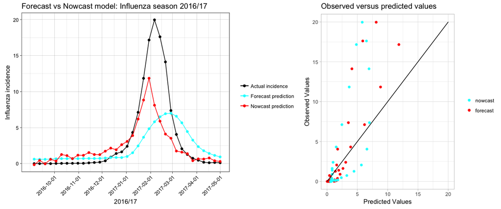

```r
# Plotting nowcast versus forecast versus observed incidence
pnf.1 = ggplot() +
  geom_line(aes(x=date.test,y=y.test,col="black")) +
  geom_point(aes(x=date.test,y=y.test,col="black")) +
  geom_line(aes(x=date.test,y=preds.null.model,col="cyan")) +
  geom_point(aes(x=date.test,y=preds.null.model,col="cyan")) +
  geom_line(aes(x=date.test,y=preds.lasso,col="red")) +
  geom_point(aes(x=date.test,y=preds.lasso,col="red")) +
  scale_color_manual(name ="",
                     values = c("black" = "black",
                                "cyan" = "cyan",
                                "red" = "red"),
                      labels = c("Actual incidence",
                                 "Forecast prediction",
                                 "Nowcast prediction")) +
  ylab("Influenza incidence") +
  xlab("2016/17") +
  ggtitle("Forecast vs Nowcast model: Influenza season 2016/17") +
  theme(plot.title = element_text(size = 10, face = "bold")) +
  #xlim(c(as.Date("2016-11-01"),as.Date("2017-05-01"))) +
  theme_linedraw() +
  scale_x_date(limits=c(as.Date("2016-09-01"),as.Date("2017-05-01")),
               breaks=c(as.Date("2016-10-01"),
                        as.Date("2016-11-01"),
                        as.Date("2016-12-01"),
                        as.Date("2017-01-01"),
                        as.Date("2017-02-01"),
                        as.Date("2017-03-01"),
                        as.Date("2017-04-01"),
                        as.Date("2017-05-01"))) +
    theme(axis.text.x = element_text(angle = 45, hjust = 1))
pnf.2 = ggplot() +
  theme_light() +
  xlab("Predicted Values") +
  ylab("Observed Values") +
  xlim(0,20)+
  ylim(0,20)+
  geom_point(aes(x=predict(models.de$result.list$M.lasso,newdata=df.test),y=y.test,col="nowcast")) +
  geom_point(aes(x=preds.null.model,y=y.test,col="forecast")) +
  geom_line(aes(x=-3:30,y=-3:30)) +
  scale_color_manual(name ="",
                     values = c("nowcast" = "red",
                                "forecast" = "cyan"),
                     labels = c("nowcast",
                                "forecast")) +
  ggtitle("Observed versus predicted values")
plot_grid(pnf.1,pnf.2,ncol=2,rel_widths = 3:1)
```

## Discussion

In this tutorial, we have provided a detailed description on how to build a (near) real-time prediction model for influenza in Germany, using freely available data from Google and Wikipedia. By combining proven techniques from previous studies, we were able to build a nowcast model with reasonable accuracy. The selected lasso regression model had better rmse than the applied forecast model. We think, our approach can be transferred to other settings easily, and that it provides robust estimates of the model performances. Further studies are required to get a better understanding of ‘what works when’. The usefulness of particular data sources and methods should be investigates systematically in different settings (countries, diseases, patient groups, etc.)

While we have touched on a few technical challenges that may occur when setting up a nowcast model, we would like to highlight the points that, we feel, are most important:

1. **Overfitting**: Gathering data from online sources can supply researchers with a huge number of potential predictors. In the training data, overfitting is a common problem, either when too many predictors are used at once, or by testing too many predictors individually (Some will match the pattern of the dependent variable just by chance). As soon as overfitted models are confronted with new observations, they fail to provide good predictions. Cautious predictor selection, and adequate methods of (cross-)validation are, therefore, essential steps when building a nowcast model.
2. **Leaking information**: This point is closely related to point 1. Leaking information from the test data set to the training data set also leads to an overestimation of the model performance. As shown above, building prediction models for time series requires special attention to the way in which predictors are selected and validation is performed. Training and test data should be handled strictly separate from each other, and only time-series cross-validation should be used to select predictors and tune nowcast models.
3. **Continuous updating and simulation**: In this tutorial, all models were created at one point in time; and their performance in the validation dataset was evaluated using a set of parameters and specifications that were fixed for the entire time span. A more rigorous and realistic assessment of the Nowcast (and forecast) model performance would include a continuous updating on a week-by-week basis. As soon as new data on actual influenza cases becomes available, the models should make use of of the information and ideally, the entire modelling procedure should be repeated every time. Thereby, the accuracy of the model could be drastically improved and growing mispredictions - as have been observed in the Google Flu Trend model - could potentially be avoided.
4. **Standards**: There are currently no standards on how to build, assess, describe or report nowcast models. Previous studies haves used numerous different approaches; or put differently, there is great uncertainty around the ‘tool set’ in digital epidemiology. While a diverse range of methods is not necessarily a bad thing, it makes it impossible to compare studies or nowcast models with each other. [Priedhorsky et al.](http://dl.acm.org/citation.cfm?doid=2998181.2998183) made a couple of important points and laid out a basic framework that could help improve the quality of future investigations. Directed towards the future use of nowcasting models, they demand: *“One must quantify the value added over traditional surveillance alone; simply matching official data well does not do this. We need evaluation metrics that are relevant to downstream uses of the model…”*.
5. **Reporting**: Scientific studies should be reported in a way so that others can reproduce its findings. In the field of Digital Epidemiology, minor differences in the specification of how to retrieve online data, or how to specify model fitting, may produce very divergent results. Thus, we think, it will often be necessary to publish source data and code alongside the manuscript, to allow incremental development of the field.

**If you have any comments or feedback, please contact us: schneider.paulpeter@gmail.com**

### References

#### Literature

Priedhorsky R, Osthus D, Daughton AR, Moran KR, Generous N, Fairchild G, Deshpande A, Del Valle SY. Measuring Global Disease with Wikipedia: Success, Failure, and a Research Agenda. InProceedings of the 2017 ACM Conference on Computer Supported Cooperative Work and Social Computing 2017 Feb 25 (pp. 1812-1834). ACM. https://dl.acm.org/citation.cfm?doid=2998181.2998183

#### Data

**German influenza incidence** Robert Koch Institute: SurvStat@RKI 2.0, https://survstat.rki.de, [query: 2017-08-07]

**Wikipedia data 2016-2017** MediaWiki contributors: REST API, https://www.mediawiki.org/w/index.php?title=REST_API&oldid=2442979 [query: 2017-08-07]

**Wikipedia data 2010-2015** Elad Vardi and Lev Muchnik www.wikishark.com [query: 2017-08-07]

**Google Correlate** Google Correlate (http://www.google.com/trends/correlate) [query: 2017-08-07]

**Google Trends** Google Trends (http://www.google.com/trends) [query: 2017-08-07]

#### R packages

*References according to the `citation()` command*

```r
# Citing used R packages
citations <- function() {
  citation.list = list()
  citation.list[[1]] =  RStudio.Version()$citation
  cit.list <- c(required_packages[order(required_packages)])
  for(i in 1:length(cit.list)) {
    ref <- citation(cit.list[i])
    citation.list[[i+1]] = ref
    }
return(citation.list)
}
citation.list =  citations()
citation.headers = c("R Studio",required_packages[order(required_packages)])
for(citation in 1:length(citation.list)){
  cat("'",citation.headers[citation],"' \n",sep="")
print(citation.list[[citation]],style="text")
cat("\n")
  }
```

```
'R Studio'
RStudio Team (2016). _RStudio: Integrated Development Environment for R_. RStudio, Inc., Boston, MA. <URL: http://www.rstudio.com/>.

'caret'
Wing MKCfJ, Weston S, Williams A, Keefer C, Engelhardt A, Cooper T, Mayer Z, Kenkel B, Team tRC, Benesty M, Lescarbeau R, Ziem A,
Scrucca L, Tang Y, Candan C and Hunt. T (2017). _caret: Classification and Regression Training_. R package version 6.0-76, <URL:
https://CRAN.R-project.org/package=caret>.

'corrplot'
Wei T and Simko V (2016). _corrplot: Visualization of a Correlation Matrix_. R package version 0.77, <URL:
https://CRAN.R-project.org/package=corrplot>.

'cowplot'
Wilke C (2016). _cowplot: Streamlined Plot Theme and Plot Annotations for 'ggplot2'_. R package version 0.7.0, <URL:
https://CRAN.R-project.org/package=cowplot>.

'Cubist'
Kuhn M, Weston S, Keefer C and Quinlan NCCcfCbR (2016). _Cubist: Rule- And Instance-Based Regression Modeling_. R package version
0.0.19, <URL: https://CRAN.R-project.org/package=Cubist>.

'devtools'
Wickham H and Chang W (2017). _devtools: Tools to Make Developing R Packages Easier_. R package version 1.13.1, <URL:
https://CRAN.R-project.org/package=devtools>.

'doParallel'
Analytics R and Weston S (2015). _doParallel: Foreach Parallel Adaptor for the 'parallel' Package_. R package version 1.0.10, <URL:
https://CRAN.R-project.org/package=doParallel>.

'dplyr'
Wickham H and Francois R (2016). _dplyr: A Grammar of Data Manipulation_. R package version 0.5.0, <URL:
https://CRAN.R-project.org/package=dplyr>.

'e1071'
Meyer D, Dimitriadou E, Hornik K, Weingessel A and Leisch F (2017). _e1071: Misc Functions of the Department of Statistics,
Probability Theory Group (Formerly: E1071), TU Wien_. R package version 1.6-8, <URL: https://CRAN.R-project.org/package=e1071>.

'earth'
Hastie SMDfmbT and wrapper. RTUAMFuwTLl (2017). _earth: Multivariate Adaptive Regression Splines_. R package version 4.5.1, <URL:
https://CRAN.R-project.org/package=earth>.

```

[output cut: 165 more lines]

```

Terry M. Therneau and Patricia M. Grambsch (2000). _Modeling Survival Data: Extending the Cox Model_. Springer, New York. ISBN
0-387-98784-3.

'TeachingDemos'
Snow G (2016). _TeachingDemos: Demonstrations for Teaching and Learning_. R package version 2.10, <URL:
https://CRAN.R-project.org/package=TeachingDemos>.

'wikipediatrend'
Meissner P and Team RC (2016). _wikipediatrend: Public Subject Attention via Wikipedia Page View Statistics_. R package version
1.1.12.90000.

'zoo'
Zeileis A and Grothendieck G (2005). “zoo: S3 Infrastructure for Regular and Irregular Time Series.” _Journal of Statistical
Software_, *14*(6), pp. 1-27. doi: 10.18637/jss.v014.i06 (URL: http://doi.org/10.18637/jss.v014.i06).
```